# Ft Riley butterfly surveys

Analysis of 2021 Regal survey assessing covariate effects

Rexstad (CREEM Univ St Andrews)https://www.creem.st-andrews.ac.uk/  
2021-10-24

We renew our investigation of the Regal butterfly data now including potential covariates. I’ve looked at only a subset of possible covariates.

Load necessary packages

```r
library(readxl)
library(Distance)
library(vioplot)
library(knitr)
library(kableExtra)
```

# Acquire data

```r
spreadsheet.regal <- "IMAP Regal Data_ALL.xlsx"
regal <- as.data.frame(read_xlsx(path=spreadsheet.regal, sheet="Sheet1"))
```

# Some renaming of fields

The `Distance` package is quite specific about the names associated with some elements of the data. For example, the field `observer` is specific to surveys that are conducted using multiple simultaneous observers to estimate detectability on the transect. As this is not the case for this survey, rename that field to `obsname` to avoid difficulties.

```r
regal$Region.Label <- regal$Region
regal$Area <- regal$`Area (ha)`
regal$Sample.Label <- regal$`Transect ID`
regal$Effort <- regal$`Transect Length (m)`
regal$distance <- regal$`Distance (m)`
names(regal)[9] <- "obsname"
regal$sample.bout <- regal$`Sample Bout`
```

Specify units used for various measurements: perpendicular distances, transect length and density estimates.

```r
bflyunits <- convert_units("meter", "meter", "hectare")
```

# Effect of covariates

Restricting attention to the utility of covariates for the density estimate from the detections pooled across sampling bouts. For illustration, I’ll focus upon the hazard rate key function. Before including in the detection function modelling, perform exploratory data analysis looking for patterns in the data. Does there appear to be an effect of these upon the distribution of detectino distances?

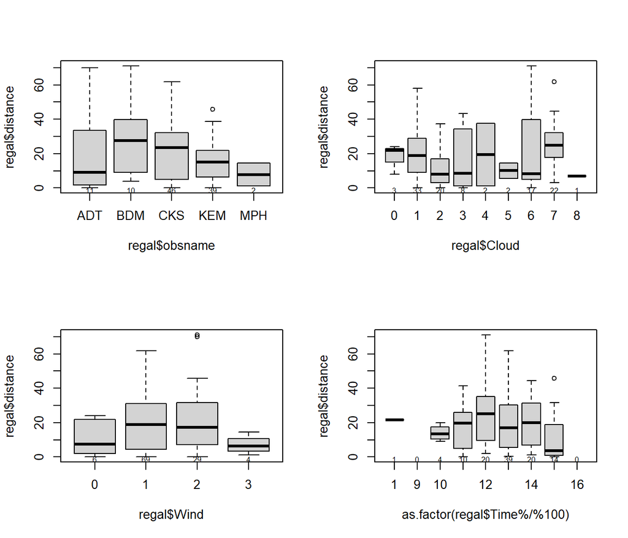

```r
par(mfrow=c(2,2))
a <- boxplot(regal$distance~regal$obsname)
text(seq(1,length(a$n)), -1, a$n, cex=0.6)
a <- boxplot(regal$distance~regal$Cloud)
text(seq(1,length(a$n)), -1, a$n, cex=0.6)
a <- boxplot(regal$distance~regal$Wind)
text(seq(1,length(a$n)), -1, a$n, cex=0.6)
a <- boxplot(regal$distance~as.factor(regal$Time %/% 100))
text(seq(1,length(a$n)), -1, a$n, cex=0.6)
```

```r
par(mfrow=c(1,1))
```

```r
mytrunc <- 45
regal$Effort <- regal$Effort * length(unique(regal$sample.bout))
m.pool.hn <- ds(regal, key="hn", convert.units = bflyunits, truncation = mytrunc)
m.pool.hr <- ds(regal, key="hr", convert.units = bflyunits, truncation = mytrunc)

pool.hr.obs <- ds(regal, key="hr", convert.units = bflyunits, truncation = mytrunc,
                  formula=~as.factor(obsname))
pool.hr.cloud <- ds(regal, key="hr", convert.units = bflyunits, truncation = mytrunc,
                    formula=~as.factor(Cloud))
pool.hr.wind <- ds(regal, key="hr", convert.units = bflyunits, truncation = mytrunc,
                   formula=~as.factor(Wind))
pool.hr.time <- ds(regal, key="hr", convert.units = bflyunits, truncation = mytrunc,
                   formula=~as.factor(Time %/% 100))
kable(summarize_ds_models(m.pool.hr, pool.hr.obs, pool.hr.cloud, pool.hr.wind, pool.hr.time)[, 2:7],
      row.names=FALSE, digits=4)
```

| Key function | Formula | C-vM p-value | $\hat{P_a}$ | se($\hat{P_a}$) | $\Delta$AIC |
| --- | --- | --- | --- | --- | --- |
| Hazard-rate | ~as.factor(Cloud) | 0.7526 | 0.2733 | 21.9195 | 0.0000 |
| Hazard-rate | ~as.factor(Time%/%100) | 0.6790 | 0.1954 | 0.2082 | 0.3684 |
| Hazard-rate | ~1 | 0.2861 | 0.4513 | 0.0958 | 4.2130 |
| Hazard-rate | ~as.factor(obsname) | 0.3245 | 0.3512 | 0.1507 | 5.2577 |
| Hazard-rate | ~as.factor(Wind) | 0.3353 | 0.3893 | 0.1245 | 7.2805 |

Take note of

- goodness of fit of all models
- estimates of $\widehat{P_a}$ of all models
  - does anyone appear to be “odd one out”?

Examine the model that is preferred according to AIC:

```r
summary(pool.hr.cloud$ddf)
```

```
Summary for ds object
Number of observations :  102
Distance range         :  0  -  45
AIC                    :  757.3857

Detection function:
 Hazard-rate key function

Detection function parameters
Scale coefficient(s):
                    estimate           se
(Intercept)        3.4051877     3.096408
as.factor(Cloud)1 -0.3839964     3.163407
as.factor(Cloud)2 -2.2673874     3.215715
as.factor(Cloud)3 -3.8228145     3.412646
as.factor(Cloud)4 -3.1512578     4.625135
as.factor(Cloud)5 -1.2559682     5.587417
as.factor(Cloud)6 -2.2776743     3.275394
as.factor(Cloud)7  1.3766218     4.877651
as.factor(Cloud)8 -1.5830290 16356.559497

Shape coefficient(s):
            estimate        se
(Intercept)        0 0.2071298

                       Estimate          SE       CV
Average p             0.2732647    21.91954 80.21359
N in covered region 373.2644387 29940.90291 80.21365
```

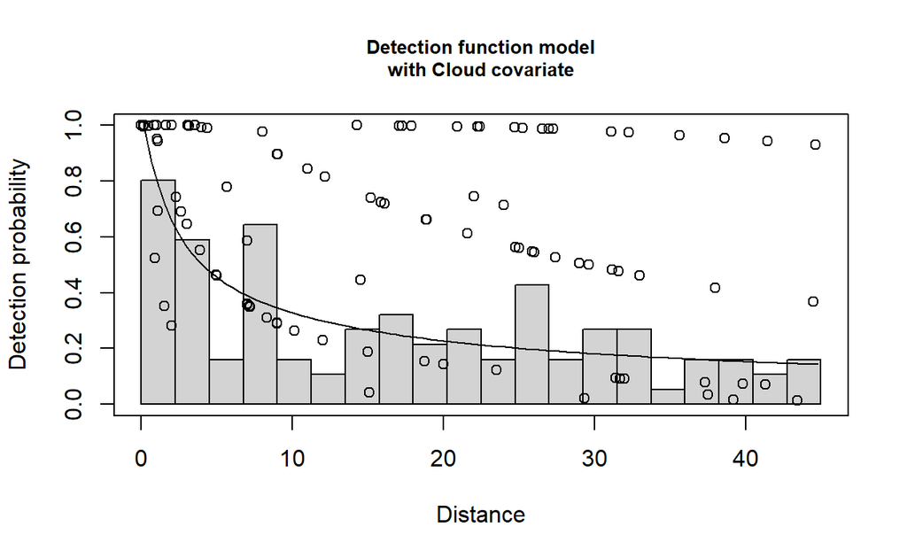

```r
plot(pool.hr.cloud, nc=20,
     main="Detection function model\nwith Cloud covariate")
```

Before going any further, note the precision with which the parameters of the detection function for the `Cloud` model are estimated.

Moving to a more plausible model, examine the model with `obsname` as a covariate. Again note the precision with which the parameters of the detection function model are estimate. What does this suggest about the strength of the `obsname` effect?

```r
summary(pool.hr.obs)
```

```
Summary for distance analysis
Number of observations :  102
Distance range         :  0  -  45

Model : Hazard-rate key function
AIC   : 762.6434

Detection function parameters
Scale coefficient(s):
                        estimate         se
(Intercept)           0.03231111   1.475442
as.factor(obsname)BDM 5.61195710 124.887274
as.factor(obsname)CKS 2.72446647   1.403947
as.factor(obsname)KEM 2.26930191   1.404190
as.factor(obsname)MPH 0.12930790   3.709794

Shape coefficient(s):
            estimate        se
(Intercept)        0 0.2756075

                       Estimate          SE        CV
Average p             0.3512217   0.1506794 0.4290151
N in covered region 290.4148394 127.2430249 0.4381423

Summary statistics:
  Region  Area CoveredArea Effort   n  k    ER        se.ER     cv.ER
1   FRMR 40873        1530 170000 102 85 6e-04 0.0001087232 0.1812053

Abundance:
  Label Estimate       se        cv      lcl      ucl       df
1 Total 7758.252 3656.098 0.4712528 3200.865 18804.44 140.9569

Density:
  Label  Estimate        se        cv        lcl     ucl       df
1 Total 0.1898136 0.0894502 0.4712528 0.07831246 0.46007 140.9569
```

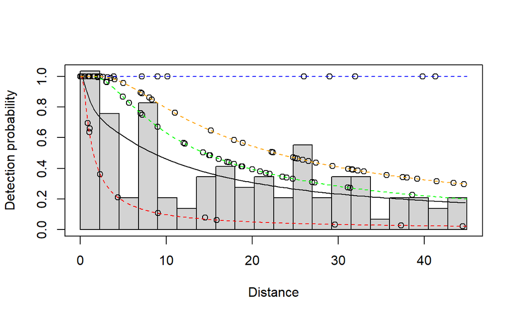

Figure 1: Plot of model with an observer covariate.

```r
plot(pool.hr.obs, nc=20)
add_df_covar_line(pool.hr.obs, data=data.frame(obsname="BDM"), col="blue")
add_df_covar_line(pool.hr.obs, data=data.frame(obsname="KEM"), col="green")
add_df_covar_line(pool.hr.obs, data=data.frame(obsname="ADT"), col="red")
add_df_covar_line(pool.hr.obs, data=data.frame(obsname="CKS"), col="orange")
```

Remind yourself: how many detections did `MPH` make?

```r
comp.ests <- rbind(m.pool.hr$dht$individuals$D,
                   pool.hr.cloud$dht$individuals$D,
                   pool.hr.obs$dht$individuals$D,
                   pool.hr.wind$dht$individuals$D,
                   pool.hr.time$dht$individuals$D)
comp.ests$Label <- c("No covar", "Cloud", "Obsname", "Wind", "Time")
kable(comp.ests[1:6], digits=4,
      caption="Regal density estimates 2021 from models with and without covariates.  Note estimate precision from Cloud model.")
```

Table 1: Regal density estimates 2021 from models with and without covariates. Note estimate precision from Cloud model.

| Label | Estimate | se | cv | lcl | ucl |
| --- | --- | --- | --- | --- | --- |
| No covar | 0.1477 | 0.0412 | 0.2790 | 0.0861 | 0.2535 |
| Cloud | 0.2440 | 19.5693 | 80.2138 | 0.0007 | 87.4217 |
| Obsname | 0.1898 | 0.0895 | 0.4713 | 0.0783 | 0.4601 |
| Wind | 0.1713 | 0.0629 | 0.3671 | 0.0849 | 0.3456 |
| Time | 0.3412 | 0.3982 | 1.1671 | 0.0545 | 2.1347 |

The results in the previous table is common. Abnormal models aside, even if AIC suggests there to be an effect of covariates on detectability, it is unlikely to manifest itself in the density estimates.